# Participation in club groups

# 1 Description of DataSchema variable

The description of harmonised variable is the following:

- Short name: `part_clubs`
- Variable label: `Participation in any club/community group`
- Variable description: `Active participation in any club/association/community group (i.e. doing sth together with the group at least several times a year) or declaration of membership`
- Domain: `Social environment`
- Value type: `categorical`
- Category coding:

| **Code** | **Category Label** |
| --- | --- |
| 0 | No |
| 1 | Yes |

- Category missings:

| **Code** | **Category Label** |
| --- | --- |
| 991 | CAPI/interviewer error |
| 992 | Impute |
| 993 | Disable to measure |
| 994 | Not attempt/not done |
| 995 | Does not answer |
| 996 | Not applicable |
| 997 | Refuse |
| 998 | Do not know |
| 999 | Missing |

# 2 Data process

## 2.1 England

### 2.1.1 Wave 1

#### 2.1.1.1 Study-specific variable description

The study-specific variables elected to be harmonised are:

- Name: `scorg1`
- Label: `Are you a member of: Political party, trade union or environmental groups`
- Categories:
  - `0 = No`
  - `1 = Yes`
- Missings:
  - `-9 = Not answered`
  - `-1 = Item not applicable`
- Name: `scorga2`
- Label: `Tenants groups, resident groups, neighbourhoold watch`
- Categories:
  - `0 = No`
  - `1 = Yes`
- Missings:
  - `-9 = Not answered`
  - `-1 = Item not applicable`
- Name: `scorg3`
- Label: `Church or other religious groups`
- Categories:
  - `0 = No`
  - `1 = Yes`
- Missings:
  - `-9 = Not answered`
  - `-1 = Item not applicable`
- Name: `scorg4`
- Label: `Charitable associations`
- Categories:
  - `0 = No`
  - `1 = Yes`
- Missings:
  - `-9 = Not answered`
  - `-1 = Item not applicable`
- Name: `scorg5`
- Label: `Education, art or music groups or evening classes`
- Categories:
  - `0 = No`
  - `1 = Yes`
- Missings:
  - `-9 = Not answered`
  - `-1 = Item not applicable`
- Name: `scorg6`
- Label: `Social club`
- Categories:
  - `0 = No`
  - `1 = Yes`
- Missings:
  - `-9 = Not answered`
  - `-1 = Item not applicable`
- Name: `scorg7`
- Label: `Sports clubs, gym, exercise classes`
- Categories:
  - `0 = No`
  - `1 = Yes`
- Missings:
  - `-9 = Not answered`
  - `-1 = Item not applicable`
- Name: `scorg8`
- Label: `Any other organisations, club or societies`
- Categories:
  - `0 = No`
  - `1 = Yes`
- Missings:
  - `-9 = Not answered`
  - `-1 = Item not applicable`
- Name: `scorg9`
- Label: `No, I am not a member of any organisations, clubs or societies`
- Categories:
  - `0 = No`
  - `1 = Yes`
- Missings:
  - `-9 = Not answered`
  - `-1 = Item not applicable`

```
## $values_table
##                -9      -1      0       1
## Frequency  485.00 1108.00 8941.0 1565.00
## Percentage   4.01    9.16   73.9   12.93
##
## $n_table
##      Sample size Missing values
## [1,]       12099              0
```

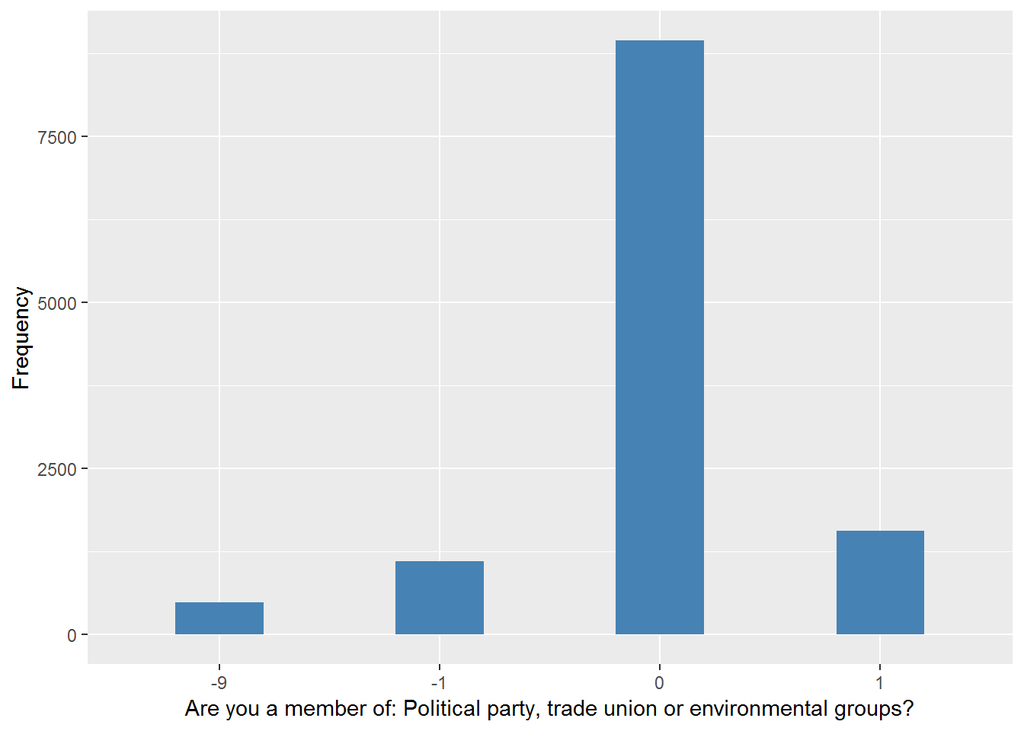

#### 2.1.1.2 Harmonisation algorithm

To compute the harmonize variable from the study-specific variable it has to be recoded as follows:

- `if any of scorg1-scorg8 equals 1 then 1`
- `if scorg9=1 or all of scorg1-scorg8 are equal 0 then 0`
- `-1 into 996`
- `-9 into 995`
- `NA into 999`

**R script:**

```r
ELSA_ds_w1 <- tibble(id = ELSA_w1_part_clubs$id)

ELSA_w1_part_clubs$scorg1 <- car::recode(as.vector(ELSA_w1_part_clubs$scorg1),
    "NA='-999'")
ELSA_w1_part_clubs$scorga2 <- car::recode(as.vector(ELSA_w1_part_clubs$scorga2),
    "NA='-999'")
ELSA_w1_part_clubs$scorg3 <- car::recode(as.vector(ELSA_w1_part_clubs$scorg3),
    "NA='-999'")
ELSA_w1_part_clubs$scorg4 <- car::recode(as.vector(ELSA_w1_part_clubs$scorg4),
    "NA='-999'")
ELSA_w1_part_clubs$scorg5 <- car::recode(as.vector(ELSA_w1_part_clubs$scorg5),
    "NA='-999'")
ELSA_w1_part_clubs$scorg6 <- car::recode(as.vector(ELSA_w1_part_clubs$scorg6),
    "NA='-999'")
ELSA_w1_part_clubs$scorg7 <- car::recode(as.vector(ELSA_w1_part_clubs$scorg7),
    "NA='-999'")
ELSA_w1_part_clubs$scorg8 <- car::recode(as.vector(ELSA_w1_part_clubs$scorg8),
    "NA='-999'")
ELSA_w1_part_clubs$scorg9 <- car::recode(as.vector(ELSA_w1_part_clubs$scorg9),
    "NA='-999'")

ELSA_ds_w1$part_clubs <- c(NA)
for (i in 1:dim(ELSA_w1_part_clubs)[1]) {
    if (ELSA_w1_part_clubs$scorg1[i] == 1 | ELSA_w1_part_clubs$scorga2[i] ==
        1 | ELSA_w1_part_clubs$scorg3[i] == 1 | ELSA_w1_part_clubs$scorg4[i] ==
        1 | ELSA_w1_part_clubs$scorg5[i] == 1 | ELSA_w1_part_clubs$scorg6[i] ==
        1 | ELSA_w1_part_clubs$scorg7[i] == 1 | ELSA_w1_part_clubs$scorg8[i] ==
        1) {
        ELSA_ds_w1$part_clubs[i] = 1
    } else if (ELSA_w1_part_clubs$scorg9[i] == 1 | (ELSA_w1_part_clubs$scorg1[i] ==
        0 & ELSA_w1_part_clubs$scorga2[i] == 0 & ELSA_w1_part_clubs$scorg3[i] ==
        0 & ELSA_w1_part_clubs$scorg4[i] == 0 & ELSA_w1_part_clubs$scorg5[i] ==
        0 & ELSA_w1_part_clubs$scorg6[i] == 0 & ELSA_w1_part_clubs$scorg7[i] ==
        0 & ELSA_w1_part_clubs$scorg8[i] == 0)) {
        ELSA_ds_w1$part_clubs[i] = 0
    } else if (ELSA_w1_part_clubs$scorg1[i] == -1 | ELSA_w1_part_clubs$scorga2[i] ==
        -1 | ELSA_w1_part_clubs$scorg3[i] == -1 | ELSA_w1_part_clubs$scorg4[i] ==
        -1 | ELSA_w1_part_clubs$scorg5[i] == -1 | ELSA_w1_part_clubs$scorg6[i] ==
        -1 | ELSA_w1_part_clubs$scorg7[i] == -1 | ELSA_w1_part_clubs$scorg8[i] ==
        -1 | ELSA_w1_part_clubs$scorg9[i] == -1) {
        ELSA_ds_w1$part_clubs[i] = 996
    } else if (ELSA_w1_part_clubs$scorg1[i] == -9 | ELSA_w1_part_clubs$scorga2[i] ==
        -9 | ELSA_w1_part_clubs$scorg3[i] == -9 | ELSA_w1_part_clubs$scorg4[i] ==
        -9 | ELSA_w1_part_clubs$scorg5[i] == -9 | ELSA_w1_part_clubs$scorg6[i] ==
        -9 | ELSA_w1_part_clubs$scorg7[i] == -9 | ELSA_w1_part_clubs$scorg8[i] ==
        -9 | ELSA_w1_part_clubs$scorg9[i] == -9) {
        ELSA_ds_w1$part_clubs[i] = 995
    }
}

ELSA_ds_w1$part_clubs <- car::recode(as.vector(ELSA_ds_w1$part_clubs), "NA='999'")
ELSA_ds_w1$part_clubs <- labelled(ELSA_ds_w1$part_clubs, labels = c(No = 0,
    Yes = 1, Missing = 999, `Do not know` = 998, Refuse = 997, `Not applicable` = 996,
    `Don't answer` = 995, `Not attempt/not done/not yet recorded` = 994, `Disable to measure` = 993,
    Impute = 992, `CAPI/interviewer error` = 991))
```

#### 2.1.1.3 Statistics of the new harmonised variable

```
## $values_table
##                  0       1
## Frequency  3241.00 7265.00
## Percentage   26.79   60.05
##
## $missing_values_table
##            991 992 993 994    995     996 997 998 999 NA
## Frequency    0   0   0   0 485.00 1108.00   0   0   0  0
## Percentage   0   0   0   0   4.01    9.16   0   0   0  0
##
## $n_table
##      Sample size Missing values
## [1,]       12099           1593
```

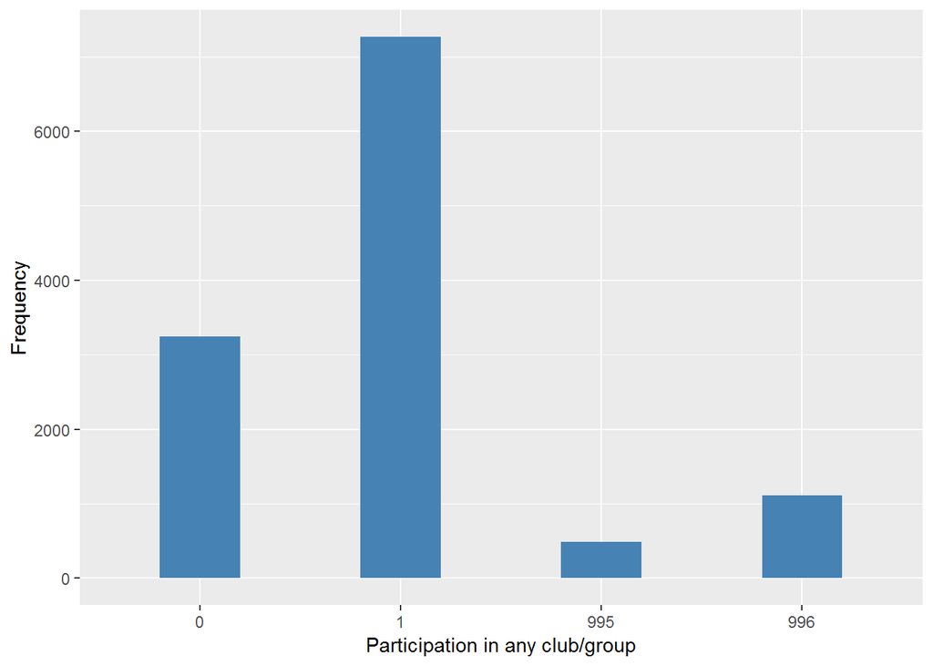

#### 2.1.1.4 Validation

### 2.1.2 Wave 2

#### 2.1.2.1 Study-specific variable description

The study-specific variable elected to be harmonised is:

- Name: `scorg01`
- Label: `Are you a member of: Political party, trade union or environmental groups`
- Categories:
  - `0 = No`
  - `1 = Yes`
- Missings:
  - `-9 = Not answered`
  - `-1 = Item not applicable`
- Name: `scorg02`
- Label: `Tenants groups, resident groups, neighbourhoold watch`
- Categories:
  - `0 = No`
  - `1 = Yes`
- Missings:
  - `-9 = Not answered`
  - `-1 = Item not applicable`
- Name: `scorg03`
- Label: `Church or other religious groups`
- Categories:
  - `0 = No`
  - `1 = Yes`
- Missings:
  - `-9 = Not answered`
  - `-1 = Item not applicable`
- Name: `scorg04`
- Label: `Charitable associations`
- Categories:
  - `0 = No`
  - `1 = Yes`
- Missings:
  - `-9 = Not answered`
  - `-1 = Item not applicable`
- Name: `scorg05`
- Label: `Education, art or music groups or evening classes`
- Categories:
  - `0 = No`
  - `1 = Yes`
- Missings:
  - `-9 = Not answered`
  - `-1 = Item not applicable`
- Name: `scorg06`
- Label: `Social club`
- Categories:
  - `0 = No`
  - `1 = Yes`
- Missings:
  - `-9 = Not answered`
  - `-1 = Item not applicable`
- Name: `scorg07`
- Label: `Sports clubs, gym, exercise classes`
- Categories:
  - `0 = No`
  - `1 = Yes`
- Missings:
  - `-9 = Not answered`
  - `-1 = Item not applicable`
- Name: `scorg08`
- Label: `Any other organisations, club or societies`
- Categories:
  - `0 = No`
  - `1 = Yes`
- Missings:
  - `-9 = Not answered`
  - `-1 = Item not applicable`
- Name: `scorg09`
- Label: `No, I am not a member of any organisations, clubs or societies`
- Categories:
  - `0 = No`
  - `1 = Yes`
- Missings:
  - `-9 = Not answered`
  - `-1 = Item not applicable`

```
## $values_table
##               -9      -1       0       1
## Frequency  594.0 1072.00 6580.00 1186.00
## Percentage   6.3   11.37   69.76   12.57
##
## $n_table
##      Sample size Missing values
## [1,]        9432              0
```

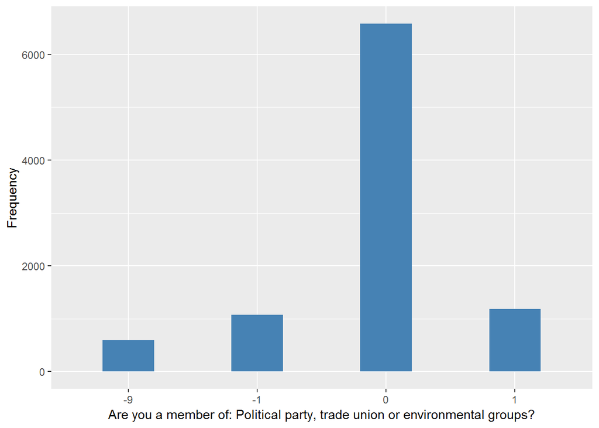

#### 2.1.2.2 Harmonisation algorithm

To compute the harmonize variable from the study-specific variable it has to be recoded as follows:

- `if any of scorg01-scorg08 equals 1 then 1`
- `if scorg09=1 or all of scorg01-scorg08 are equal 0 then 0`
- `-1 into 996`
- `-9 into 995`
- `NA into 999`

**R script:**

```r
ELSA_ds_w2 <- tibble(id = ELSA_w2_part_clubs$id)

ELSA_w2_part_clubs$scorg01 <- car::recode(as.vector(ELSA_w2_part_clubs$scorg01),
    "NA='-999'")
ELSA_w2_part_clubs$scorg02 <- car::recode(as.vector(ELSA_w2_part_clubs$scorg02),
    "NA='-999'")
ELSA_w2_part_clubs$scorg03 <- car::recode(as.vector(ELSA_w2_part_clubs$scorg03),
    "NA='-999'")
ELSA_w2_part_clubs$scorg04 <- car::recode(as.vector(ELSA_w2_part_clubs$scorg04),
    "NA='-999'")
ELSA_w2_part_clubs$scorg05 <- car::recode(as.vector(ELSA_w2_part_clubs$scorg05),
    "NA='-999'")
ELSA_w2_part_clubs$scorg06 <- car::recode(as.vector(ELSA_w2_part_clubs$scorg06),
    "NA='-999'")
ELSA_w2_part_clubs$scorg07 <- car::recode(as.vector(ELSA_w2_part_clubs$scorg07),
    "NA='-999'")
ELSA_w2_part_clubs$scorg08 <- car::recode(as.vector(ELSA_w2_part_clubs$scorg08),
    "NA='-999'")
ELSA_w2_part_clubs$scorg09 <- car::recode(as.vector(ELSA_w2_part_clubs$scorg09),
    "NA='-999'")

ELSA_ds_w2$part_clubs <- c(NA)
for (i in 1:dim(ELSA_w2_part_clubs)[1]) {
    if (ELSA_w2_part_clubs$scorg01[i] == 1 | ELSA_w2_part_clubs$scorg02[i] ==
        1 | ELSA_w2_part_clubs$scorg03[i] == 1 | ELSA_w2_part_clubs$scorg04[i] ==
        1 | ELSA_w2_part_clubs$scorg05[i] == 1 | ELSA_w2_part_clubs$scorg06[i] ==
        1 | ELSA_w2_part_clubs$scorg07[i] == 1 | ELSA_w2_part_clubs$scorg08[i] ==
        1) {
        ELSA_ds_w2$part_clubs[i] = 1
    } else if (ELSA_w2_part_clubs$scorg09[i] == 1 | (ELSA_w2_part_clubs$scorg01[i] ==
        0 & ELSA_w2_part_clubs$scorg02[i] == 0 & ELSA_w2_part_clubs$scorg03[i] ==
        0 & ELSA_w2_part_clubs$scorg04[i] == 0 & ELSA_w2_part_clubs$scorg05[i] ==
        0 & ELSA_w2_part_clubs$scorg06[i] == 0 & ELSA_w2_part_clubs$scorg07[i] ==
        0 & ELSA_w2_part_clubs$scorg08[i] == 0)) {
        ELSA_ds_w2$part_clubs[i] = 0
    } else if (ELSA_w2_part_clubs$scorg01[i] == -1 | ELSA_w2_part_clubs$scorg02[i] ==
        -1 | ELSA_w2_part_clubs$scorg03[i] == -1 | ELSA_w2_part_clubs$scorg04[i] ==
        -1 | ELSA_w2_part_clubs$scorg05[i] == -1 | ELSA_w2_part_clubs$scorg06[i] ==
        -1 | ELSA_w2_part_clubs$scorg07[i] == -1 | ELSA_w2_part_clubs$scorg08[i] ==
        -1 | ELSA_w2_part_clubs$scorg09[i] == -1) {
        ELSA_ds_w2$part_clubs[i] = 996
    } else if (ELSA_w2_part_clubs$scorg01[i] == -9 | ELSA_w2_part_clubs$scorg02[i] ==
        -9 | ELSA_w2_part_clubs$scorg03[i] == -9 | ELSA_w2_part_clubs$scorg04[i] ==
        -9 | ELSA_w2_part_clubs$scorg05[i] == -9 | ELSA_w2_part_clubs$scorg06[i] ==
        -9 | ELSA_w2_part_clubs$scorg07[i] == -9 | ELSA_w2_part_clubs$scorg08[i] ==
        -9 | ELSA_w2_part_clubs$scorg09[i] == -9) {
        ELSA_ds_w2$part_clubs[i] = 995
    }
}

ELSA_ds_w2$part_clubs <- car::recode(as.vector(ELSA_ds_w2$part_clubs), "NA='999'")
ELSA_ds_w2$part_clubs <- labelled(ELSA_ds_w2$part_clubs, labels = c(No = 0,
    Yes = 1, Missing = 999, `Do not know` = 998, Refuse = 997, `Not applicable` = 996,
    `Don't answer` = 995, `Not attempt/not done/not yet recorded` = 994, `Disable to measure` = 993,
    Impute = 992, `CAPI/interviewer error` = 991))
```

#### 2.1.2.3 Statistics of the new harmonised variable

```
## $values_table
##                  0      1
## Frequency  2022.00 5744.0
## Percentage   21.44   60.9
##
## $missing_values_table
##            991 992 993 994   995     996 997 998 999 NA
## Frequency    0   0   0   0 594.0 1072.00   0   0   0  0
## Percentage   0   0   0   0   6.3   11.37   0   0   0  0
##
## $n_table
##      Sample size Missing values
## [1,]        9432           1666
```

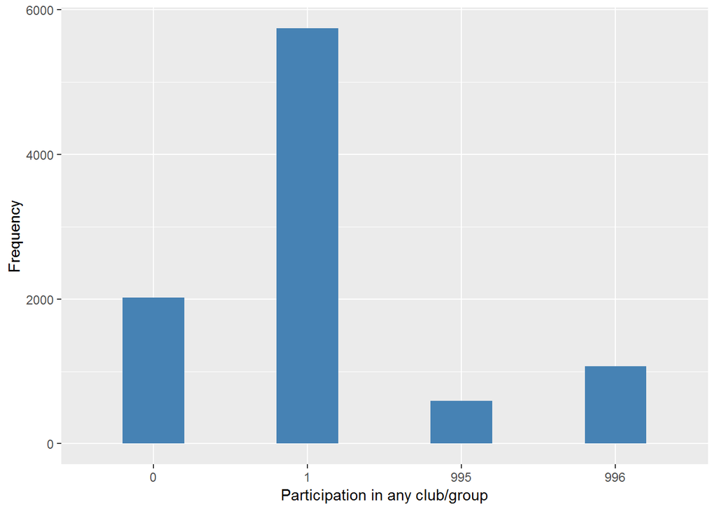

#### 2.1.2.4 Validation

### 2.1.3 Wave 3

#### 2.1.3.1 Study-specific variable description

The study-specific variable elected to be harmonised is:

- Name: `scorg01`
- Label: `Are you a member of: Political party, trade union or environmental groups`
- Categories:
  - `0 = No`
  - `1 = Yes`
- Missings:
  - `-9 = Not answered`
  - `-8 = Don't know`
  - `-1 = Item not applicable`
- Name: `scorg02`
- Label: `Tenants groups, resident groups, neighbourhoold watch`
- Categories:
  - `0 = No`
  - `1 = Yes`
- Missings:
  - `-9 = Not answered`
  - `-8 = Don't know`
  - `-1 = Item not applicable`
- Name: `scorg03`
- Label: `Church or other religious groups`
- Categories:
  - `0 = No`
  - `1 = Yes`
- Missings:
  - `-9 = Not answered`
  - `-8 = Don't know`
  - `-1 = Item not applicable`
- Name: `scorg04`
- Label: `Charitable associations`
- Categories:
  - `0 = No`
  - `1 = Yes`
- Missings:
  - `-9 = Not answered`
  - `-8 = Don't know`
  - `-1 = Item not applicable`
- Name: `scorg05`
- Label: `Education, art or music groups or evening classes`
- Categories:
  - `0 = No`
  - `1 = Yes`
- Missings:
  - `-9 = Not answered`
  - `-8 = Don't know`
  - `-1 = Item not applicable`
- Name: `scorg06`
- Label: `Social club`
- Categories:
  - `0 = No`
  - `1 = Yes`
- Missings:
  - `-9 = Not answered`
  - `-8 = Don't know`
  - `-1 = Item not applicable`
- Name: `scorg07`
- Label: `Sports clubs, gym, exercise classes`
- Categories:
  - `0 = No`
  - `1 = Yes`
- Missings:
  - `-9 = Not answered`
  - `-8 = Don't know`
  - `-1 = Item not applicable`
- Name: `scorg08`
- Label: `Any other organisations, club or societies`
- Categories:
  - `0 = No`
  - `1 = Yes`
- Missings:
  - `-9 = Not answered`
  - `-8 = Don't know`
  - `-1 = Item not applicable`
- Name: `scorg09`
- Label: `No, I am not a member of any organisations, clubs or societies`
- Categories:
  - `0 = No`
  - `1 = Yes`
- Missings:
  - `-9 = Not answered`
  - `-8 = Don't know`
  - `-1 = Item not applicable`

```
## $values_table
##               -9      -1       0       1
## Frequency  479.0 1527.00 6636.00 1129.00
## Percentage   4.9   15.63   67.92   11.55
##
## $n_table
##      Sample size Missing values
## [1,]        9771              0
```

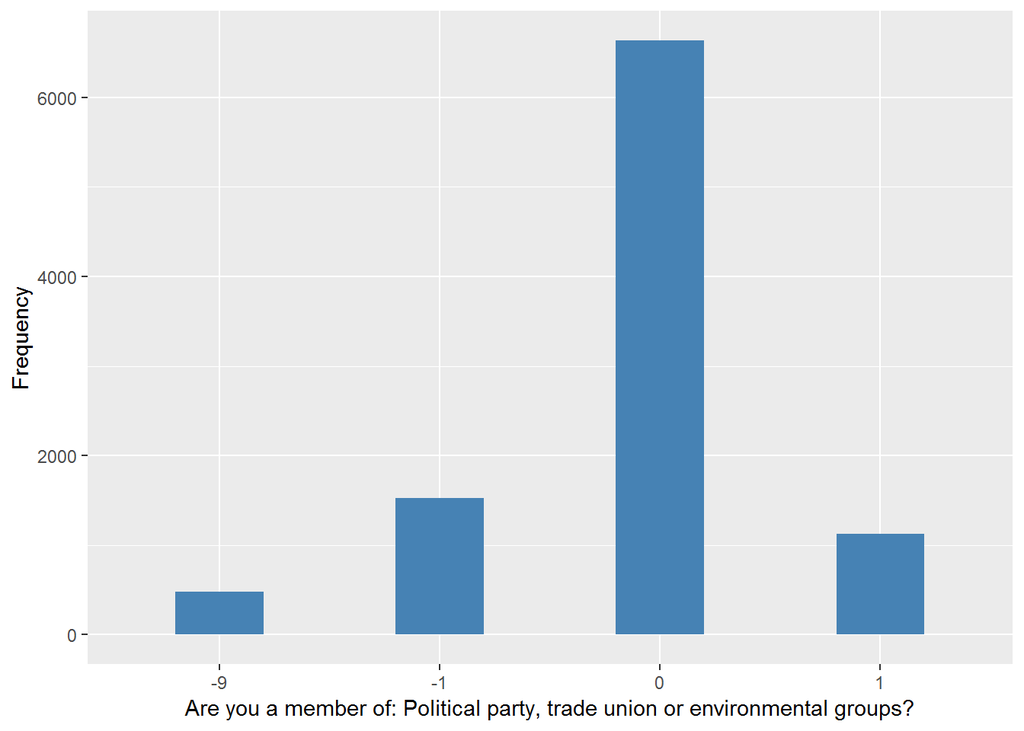

#### 2.1.3.2 Harmonisation algorithm

To compute the harmonize variable from the study-specific variable it has to be recoded as follows:

- `if any of scorg01-scorg08 equals 1 then 1`
- `if scorg09=1 or all of scorg01-scorg08 are equal 0 then 0`
- `-1 into 996`
- `-8 into 998`
- `-9 into 995`
- `NA into 999`

**R script:**

```r
ELSA_ds_w3 <- tibble(id = ELSA_w3_part_clubs$id)

ELSA_w3_part_clubs$scorg01 <- car::recode(as.vector(ELSA_w3_part_clubs$scorg01),
    "NA='-999'")
ELSA_w3_part_clubs$scorg02 <- car::recode(as.vector(ELSA_w3_part_clubs$scorg02),
    "NA='-999'")
ELSA_w3_part_clubs$scorg03 <- car::recode(as.vector(ELSA_w3_part_clubs$scorg03),
    "NA='-999'")
ELSA_w3_part_clubs$scorg04 <- car::recode(as.vector(ELSA_w3_part_clubs$scorg04),
    "NA='-999'")
ELSA_w3_part_clubs$scorg05 <- car::recode(as.vector(ELSA_w3_part_clubs$scorg05),
    "NA='-999'")
ELSA_w3_part_clubs$scorg06 <- car::recode(as.vector(ELSA_w3_part_clubs$scorg06),
    "NA='-999'")
ELSA_w3_part_clubs$scorg07 <- car::recode(as.vector(ELSA_w3_part_clubs$scorg07),
    "NA='-999'")
ELSA_w3_part_clubs$scorg08 <- car::recode(as.vector(ELSA_w3_part_clubs$scorg08),
    "NA='-999'")
ELSA_w3_part_clubs$scorg09 <- car::recode(as.vector(ELSA_w3_part_clubs$scorg09),
    "NA='-999'")

ELSA_ds_w3$part_clubs <- c(NA)
for (i in 1:dim(ELSA_w3_part_clubs)[1]) {
    if (ELSA_w3_part_clubs$scorg01[i] == 1 | ELSA_w3_part_clubs$scorg02[i] ==
        1 | ELSA_w3_part_clubs$scorg03[i] == 1 | ELSA_w3_part_clubs$scorg04[i] ==
        1 | ELSA_w3_part_clubs$scorg05[i] == 1 | ELSA_w3_part_clubs$scorg06[i] ==
        1 | ELSA_w3_part_clubs$scorg07[i] == 1 | ELSA_w3_part_clubs$scorg08[i] ==
        1) {
        ELSA_ds_w3$part_clubs[i] = 1
    } else if (ELSA_w3_part_clubs$scorg09[i] == 1 | (ELSA_w3_part_clubs$scorg01[i] ==
        0 & ELSA_w3_part_clubs$scorg02[i] == 0 & ELSA_w3_part_clubs$scorg03[i] ==
        0 & ELSA_w3_part_clubs$scorg04[i] == 0 & ELSA_w3_part_clubs$scorg05[i] ==
        0 & ELSA_w3_part_clubs$scorg06[i] == 0 & ELSA_w3_part_clubs$scorg07[i] ==
        0 & ELSA_w3_part_clubs$scorg08[i] == 0)) {
        ELSA_ds_w3$part_clubs[i] = 0
    } else if (ELSA_w3_part_clubs$scorg01[i] == -1 | ELSA_w3_part_clubs$scorg02[i] ==
        -1 | ELSA_w3_part_clubs$scorg03[i] == -1 | ELSA_w3_part_clubs$scorg04[i] ==
        -1 | ELSA_w3_part_clubs$scorg05[i] == -1 | ELSA_w3_part_clubs$scorg06[i] ==
        -1 | ELSA_w3_part_clubs$scorg07[i] == -1 | ELSA_w3_part_clubs$scorg08[i] ==
        -1 | ELSA_w3_part_clubs$scorg09[i] == -1) {
        ELSA_ds_w3$part_clubs[i] = 996
    } else if (ELSA_w3_part_clubs$scorg01[i] == -8 | ELSA_w3_part_clubs$scorg02[i] ==
        -8 | ELSA_w3_part_clubs$scorg03[i] == -8 | ELSA_w3_part_clubs$scorg04[i] ==
        -8 | ELSA_w3_part_clubs$scorg05[i] == -8 | ELSA_w3_part_clubs$scorg06[i] ==
        -8 | ELSA_w3_part_clubs$scorg07[i] == -8 | ELSA_w3_part_clubs$scorg08[i] ==
        -8 | ELSA_w3_part_clubs$scorg09[i] == -8) {
        ELSA_ds_w3$part_clubs[i] = 998
    } else if (ELSA_w3_part_clubs$scorg01[i] == -9 | ELSA_w3_part_clubs$scorg02[i] ==
        -9 | ELSA_w3_part_clubs$scorg03[i] == -9 | ELSA_w3_part_clubs$scorg04[i] ==
        -9 | ELSA_w3_part_clubs$scorg05[i] == -9 | ELSA_w3_part_clubs$scorg06[i] ==
        -9 | ELSA_w3_part_clubs$scorg07[i] == -9 | ELSA_w3_part_clubs$scorg08[i] ==
        -9 | ELSA_w3_part_clubs$scorg09[i] == -9) {
        ELSA_ds_w3$part_clubs[i] = 995
    }
}

ELSA_ds_w3$part_clubs <- car::recode(as.vector(ELSA_ds_w3$part_clubs), "NA='999'")
ELSA_ds_w3$part_clubs <- labelled(ELSA_ds_w3$part_clubs, labels = c(No = 0,
    Yes = 1, Missing = 999, `Do not know` = 998, Refuse = 997, `Not applicable` = 996,
    `Don't answer` = 995, `Not attempt/not done/not yet recorded` = 994, `Disable to measure` = 993,
    Impute = 992, `CAPI/interviewer error` = 991))
```

#### 2.1.3.3 Statistics of the new harmonised variable

```
## $values_table
##                  0       1
## Frequency  2187.00 5578.00
## Percentage   22.38   57.09
##
## $missing_values_table
##            991 992 993 994   995     996 997 998 999 NA
## Frequency    0   0   0   0 479.0 1527.00   0   0   0  0
## Percentage   0   0   0   0   4.9   15.63   0   0   0  0
##
## $n_table
##      Sample size Missing values
## [1,]        9771           2006
```

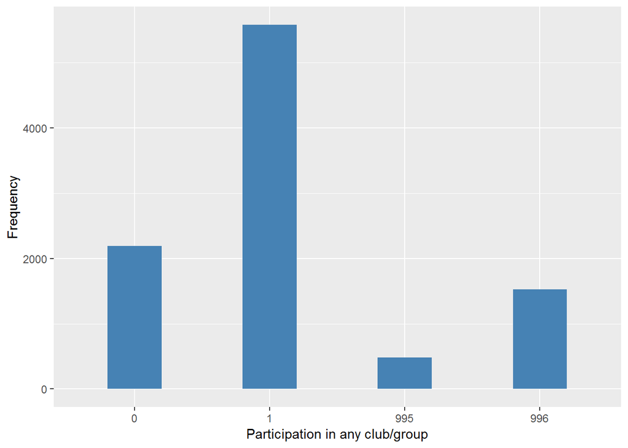

#### 2.1.3.4 Validation

### 2.1.4 Wave 4

#### 2.1.4.1 Study-specific variable description

The study-specific variable elected to be harmonised is:

- Name: `scorg01`
- Label: `Are you a member of: Political party, trade union or environmental groups`
- Categories:
  - `0 = No`
  - `1 = Yes`
- Missings:
  - `-9 = Not answered`
  - `-8 = Don't know`
  - `-1 = Item not applicable`
- Name: `scorg02`
- Label: `Tenants groups, resident groups, neighbourhoold watch`
- Categories:
  - `0 = No`
  - `1 = Yes`
- Missings:
  - `-9 = Not answered`
  - `-8 = Don't know`
  - `-1 = Item not applicable`
- Name: `scorg03`
- Label: `Church or other religious groups`
- Categories:
  - `0 = No`
  - `1 = Yes`
- Missings:
  - `-9 = Not answered`
  - `-8 = Don't know`
  - `-1 = Item not applicable`
- Name: `scorg04`
- Label: `Charitable associations`
- Categories:
  - `0 = No`
  - `1 = Yes`
- Missings:
  - `-9 = Not answered`
  - `-8 = Don't know`
  - `-1 = Item not applicable`
- Name: `scorg05`
- Label: `Education, art or music groups or evening classes`
- Categories:
  - `0 = No`
  - `1 = Yes`
- Missings:
  - `-9 = Not answered`
  - `-8 = Don't know`
  - `-1 = Item not applicable`
- Name: `scorg06`
- Label: `Social club`
- Categories:
  - `0 = No`
  - `1 = Yes`
- Missings:
  - `-9 = Not answered`
  - `-8 = Don't know`
  - `-1 = Item not applicable`
- Name: `scorg07`
- Label: `Sports clubs, gym, exercise classes`
- Categories:
  - `0 = No`
  - `1 = Yes`
- Missings:
  - `-9 = Not answered`
  - `-8 = Don't know`
  - `-1 = Item not applicable`
- Name: `scorg08`
- Label: `Any other organisations, club or societies`
- Categories:
  - `0 = No`
  - `1 = Yes`
- Missings:
  - `-9 = Not answered`
  - `-8 = Don't know`
  - `-1 = Item not applicable`
- Name: `scorg09`
- Label: `No, I am not a member of any organisations, clubs or societies`
- Categories:
  - `0 = No`
  - `1 = Yes`
- Missings:
  - `-9 = Not answered`
  - `-8 = Don't know`
  - `-1 = Item not applicable`

```
## $values_table
##                -9      -1       0       1
## Frequency  462.00 1708.00 7608.00 1272.00
## Percentage   4.18   15.46   68.85   11.51
##
## $n_table
##      Sample size Missing values
## [1,]       11050              0
```

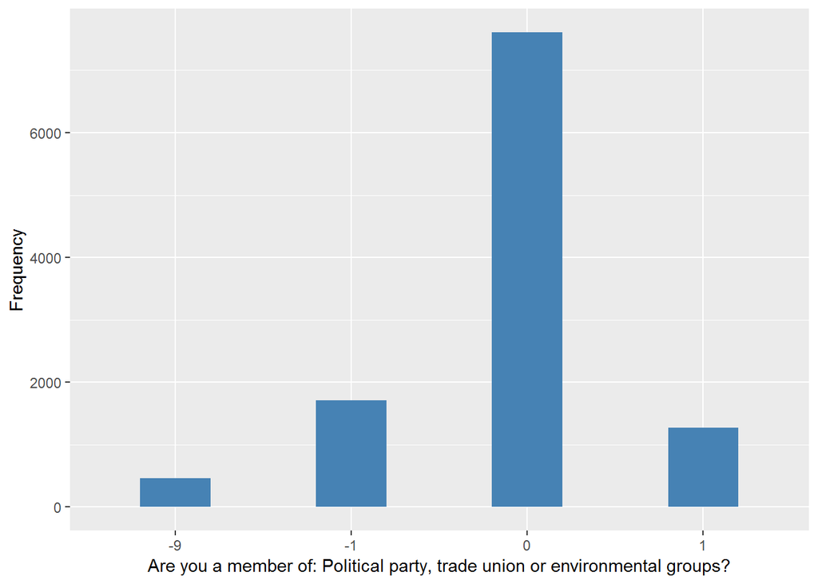

#### 2.1.4.2 Harmonisation algorithm

To compute the harmonize variable from the study-specific variable it has to be recoded as follows:

- `if any of scorg01-scorg08 equals 1 then 1`
- `if scorg09=1 or all of scorg01-scorg08 are equal 0 then 0`
- `-1 into 996`
- `-8 into 998`
- `-9 into 995`
- `NA into 999`

**R script:**

```r
ELSA_ds_w4 <- tibble(id = ELSA_w4_part_clubs$id)

ELSA_w4_part_clubs$scorg01 <- car::recode(as.vector(ELSA_w4_part_clubs$scorg01),
    "NA='-999'")
ELSA_w4_part_clubs$scorg02 <- car::recode(as.vector(ELSA_w4_part_clubs$scorg02),
    "NA='-999'")
ELSA_w4_part_clubs$scorg03 <- car::recode(as.vector(ELSA_w4_part_clubs$scorg03),
    "NA='-999'")
ELSA_w4_part_clubs$scorg04 <- car::recode(as.vector(ELSA_w4_part_clubs$scorg04),
    "NA='-999'")
ELSA_w4_part_clubs$scorg05 <- car::recode(as.vector(ELSA_w4_part_clubs$scorg05),
    "NA='-999'")
ELSA_w4_part_clubs$scorg06 <- car::recode(as.vector(ELSA_w4_part_clubs$scorg06),
    "NA='-999'")
ELSA_w4_part_clubs$scorg07 <- car::recode(as.vector(ELSA_w4_part_clubs$scorg07),
    "NA='-999'")
ELSA_w4_part_clubs$scorg08 <- car::recode(as.vector(ELSA_w4_part_clubs$scorg08),
    "NA='-999'")
ELSA_w4_part_clubs$scorg09 <- car::recode(as.vector(ELSA_w4_part_clubs$scorg09),
    "NA='-999'")

ELSA_ds_w4$part_clubs <- c(NA)
for (i in 1:dim(ELSA_w4_part_clubs)[1]) {
    if (ELSA_w4_part_clubs$scorg01[i] == 1 | ELSA_w4_part_clubs$scorg02[i] ==
        1 | ELSA_w4_part_clubs$scorg03[i] == 1 | ELSA_w4_part_clubs$scorg04[i] ==
        1 | ELSA_w4_part_clubs$scorg05[i] == 1 | ELSA_w4_part_clubs$scorg06[i] ==
        1 | ELSA_w4_part_clubs$scorg07[i] == 1 | ELSA_w4_part_clubs$scorg08[i] ==
        1) {
        ELSA_ds_w4$part_clubs[i] = 1
    } else if (ELSA_w4_part_clubs$scorg09[i] == 1 | (ELSA_w4_part_clubs$scorg01[i] ==
        0 & ELSA_w4_part_clubs$scorg02[i] == 0 & ELSA_w4_part_clubs$scorg03[i] ==
        0 & ELSA_w4_part_clubs$scorg04[i] == 0 & ELSA_w4_part_clubs$scorg05[i] ==
        0 & ELSA_w4_part_clubs$scorg06[i] == 0 & ELSA_w4_part_clubs$scorg07[i] ==
        0 & ELSA_w4_part_clubs$scorg08[i] == 0)) {
        ELSA_ds_w4$part_clubs[i] = 0
    } else if (ELSA_w4_part_clubs$scorg01[i] == -1 | ELSA_w4_part_clubs$scorg02[i] ==
        -1 | ELSA_w4_part_clubs$scorg03[i] == -1 | ELSA_w4_part_clubs$scorg04[i] ==
        -1 | ELSA_w4_part_clubs$scorg05[i] == -1 | ELSA_w4_part_clubs$scorg06[i] ==
        -1 | ELSA_w4_part_clubs$scorg07[i] == -1 | ELSA_w4_part_clubs$scorg08[i] ==
        -1 | ELSA_w4_part_clubs$scorg09[i] == -1) {
        ELSA_ds_w4$part_clubs[i] = 996
    } else if (ELSA_w4_part_clubs$scorg01[i] == -8 | ELSA_w4_part_clubs$scorg02[i] ==
        -8 | ELSA_w4_part_clubs$scorg03[i] == -8 | ELSA_w4_part_clubs$scorg04[i] ==
        -8 | ELSA_w4_part_clubs$scorg05[i] == -8 | ELSA_w4_part_clubs$scorg06[i] ==
        -8 | ELSA_w4_part_clubs$scorg07[i] == -8 | ELSA_w4_part_clubs$scorg08[i] ==
        -8 | ELSA_w4_part_clubs$scorg09[i] == -8) {
        ELSA_ds_w4$part_clubs[i] = 998
    } else if (ELSA_w4_part_clubs$scorg01[i] == -9 | ELSA_w4_part_clubs$scorg02[i] ==
        -9 | ELSA_w4_part_clubs$scorg03[i] == -9 | ELSA_w4_part_clubs$scorg04[i] ==
        -9 | ELSA_w4_part_clubs$scorg05[i] == -9 | ELSA_w4_part_clubs$scorg06[i] ==
        -9 | ELSA_w4_part_clubs$scorg07[i] == -9 | ELSA_w4_part_clubs$scorg08[i] ==
        -9 | ELSA_w4_part_clubs$scorg09[i] == -9) {
        ELSA_ds_w4$part_clubs[i] = 995
    }
}

ELSA_ds_w4$part_clubs <- car::recode(as.vector(ELSA_ds_w4$part_clubs), "NA='999'")
ELSA_ds_w4$part_clubs <- labelled(ELSA_ds_w4$part_clubs, labels = c(No = 0,
    Yes = 1, Missing = 999, `Do not know` = 998, Refuse = 997, `Not applicable` = 996,
    `Don't answer` = 995, `Not attempt/not done/not yet recorded` = 994, `Disable to measure` = 993,
    Impute = 992, `CAPI/interviewer error` = 991))
```

#### 2.1.4.3 Statistics of the new harmonised variable

```
## $values_table
##                  0       1
## Frequency  2561.00 6319.00
## Percentage   23.18   57.19
##
## $missing_values_table
##            991 992 993 994    995     996 997 998 999 NA
## Frequency    0   0   0   0 462.00 1708.00   0   0   0  0
## Percentage   0   0   0   0   4.18   15.46   0   0   0  0
##
## $n_table
##      Sample size Missing values
## [1,]       11050           2170
```

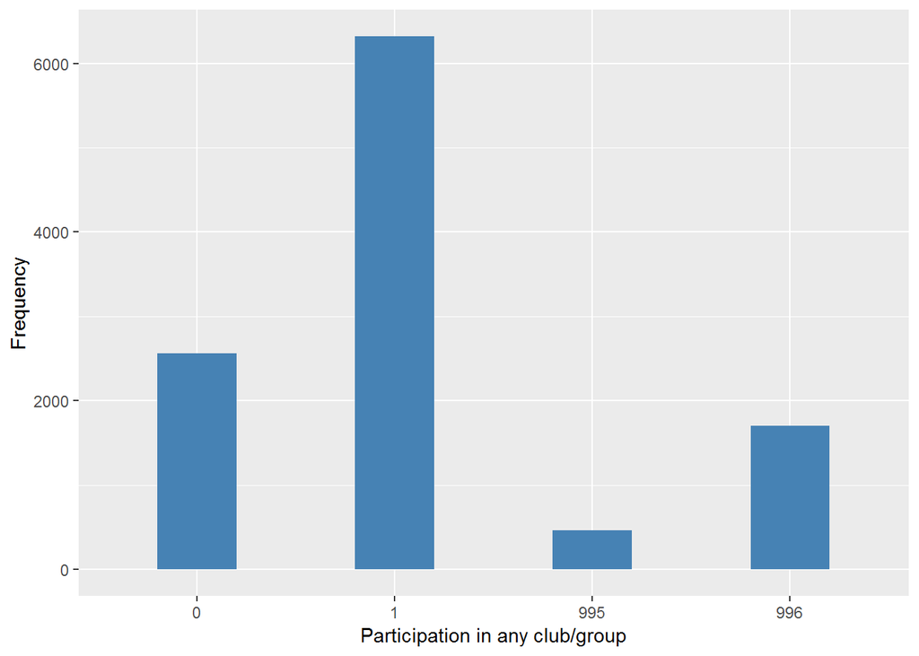

#### 2.1.4.4 Validation

### 2.1.5 Wave 5

#### 2.1.5.1 Study-specific variable description

The study-specific variable elected to be harmonised is:

- Name: `scorg01`
- Label: `Are you a member of: Political party, trade union or environmental groups`
- Categories:
  - `0 = No`
  - `1 = Yes`
- Missings:
  - `-9 = Not answered`
  - `-8 = Don't know`
  - `-2 = Schedule Not Applicable`
  - `-1 = Item not applicable`
- Name: `scorg02`
- Label: `Tenants groups, resident groups, neighbourhoold watch`
- Categories:
  - `0 = No`
  - `1 = Yes`
- Missings:
  - `-9 = Not answered`
  - `-8 = Don't know`
  - `-2 = Schedule Not Applicable`
  - `-1 = Item not applicable`
- Name: `scorg03`
- Label: `Church or other religious groups`
- Categories:
  - `0 = No`
  - `1 = Yes`
- Missings:
  - `-9 = Not answered`
  - `-8 = Don't know`
  - `-2 = Schedule Not Applicable`
  - `-1 = Item not applicable`
- Name: `scorg04`
- Label: `Charitable associations`
- Categories:
  - `0 = No`
  - `1 = Yes`
- Missings:
  - `-9 = Not answered`
  - `-8 = Don't know`
  - `-2 = Schedule Not Applicable`
  - `-1 = Item not applicable`
- Name: `scorg05`
- Label: `Education, art or music groups or evening classes`
- Categories:
  - `0 = No`
  - `1 = Yes`
- Missings:
  - `-9 = Not answered`
  - `-8 = Don't know`
  - `-2 = Schedule Not Applicable`
  - `-1 = Item not applicable`
- Name: `scorg06`
- Label: `Social club`
- Categories:
  - `0 = No`
  - `1 = Yes`
- Missings:
  - `-9 = Not answered`
  - `-8 = Don't know`
  - `-1 = Item not applicable`
- Name: `scorg07`
- Label: `Sports clubs, gym, exercise classes`
- Categories:
  - `0 = No`
  - `1 = Yes`
- Missings:
  - `-9 = Not answered`
  - `-8 = Don't know`
  - `-2 = Schedule Not Applicable`
  - `-1 = Item not applicable`
- Name: `scorg08`
- Label: `Any other organisations, club or societies`
- Categories:
  - `0 = No`
  - `1 = Yes`
- Missings:
  - `-9 = Not answered`
  - `-8 = Don't know`
  - `-2 = Schedule Not Applicable`
  - `-1 = Item not applicable`
- Name: `scorg09`
- Label: `No, I am not a member of any organisations, clubs or societies`
- Categories:
  - `0 = No`
  - `1 = Yes`
- Missings:
  - `-9 = Not answered`
  - `-8 = Don't know`
  - `-2 = Schedule Not Applicable`
  - `-1 = Item not applicable`

```
## $values_table
##                -9      -2       0      1
## Frequency  485.00 1244.00 7374.00 1171.0
## Percentage   4.72   12.11   71.77   11.4
##
## $n_table
##      Sample size Missing values
## [1,]       10274              0
```

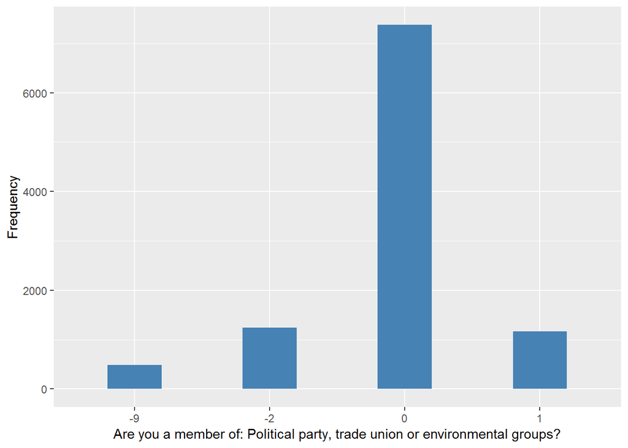

#### 2.1.5.2 Harmonisation algorithm

To compute the harmonize variable from the study-specific variable it has to be recoded as follows:

- `if any of scorg01-scorg08 equals 1 then 1`
- `if scorg09=1 or all of scorg01-scorg08 are equal 0 then 0`
- `-1 or -2 into 996`
- `-8 into 998`
- `-9 into 995`
- `NA into 999`

**R script:**

```r
ELSA_ds_w5 <- tibble(id = ELSA_w5_part_clubs$id)

ELSA_w5_part_clubs$scorg01 <- car::recode(as.vector(ELSA_w5_part_clubs$scorg01),
    "NA='-999'")
ELSA_w5_part_clubs$scorg02 <- car::recode(as.vector(ELSA_w5_part_clubs$scorg02),
    "NA='-999'")
ELSA_w5_part_clubs$scorg03 <- car::recode(as.vector(ELSA_w5_part_clubs$scorg03),
    "NA='-999'")
ELSA_w5_part_clubs$scorg04 <- car::recode(as.vector(ELSA_w5_part_clubs$scorg04),
    "NA='-999'")
ELSA_w5_part_clubs$scorg05 <- car::recode(as.vector(ELSA_w5_part_clubs$scorg05),
    "NA='-999'")
ELSA_w5_part_clubs$scorg06 <- car::recode(as.vector(ELSA_w5_part_clubs$scorg06),
    "NA='-999'")
ELSA_w5_part_clubs$scorg07 <- car::recode(as.vector(ELSA_w5_part_clubs$scorg07),
    "NA='-999'")
ELSA_w5_part_clubs$scorg08 <- car::recode(as.vector(ELSA_w5_part_clubs$scorg08),
    "NA='-999'")
ELSA_w5_part_clubs$scorg09 <- car::recode(as.vector(ELSA_w5_part_clubs$scorg09),
    "NA='-999'")

ELSA_ds_w5$part_clubs <- c(NA)
for (i in 1:dim(ELSA_w5_part_clubs)[1]) {
    if (ELSA_w5_part_clubs$scorg01[i] == 1 | ELSA_w5_part_clubs$scorg02[i] ==
        1 | ELSA_w5_part_clubs$scorg03[i] == 1 | ELSA_w5_part_clubs$scorg04[i] ==
        1 | ELSA_w5_part_clubs$scorg05[i] == 1 | ELSA_w5_part_clubs$scorg06[i] ==
        1 | ELSA_w5_part_clubs$scorg07[i] == 1 | ELSA_w5_part_clubs$scorg08[i] ==
        1) {
        ELSA_ds_w5$part_clubs[i] = 1
    } else if (ELSA_w5_part_clubs$scorg09[i] == 1 | (ELSA_w5_part_clubs$scorg01[i] ==
        0 & ELSA_w5_part_clubs$scorg02[i] == 0 & ELSA_w5_part_clubs$scorg03[i] ==
        0 & ELSA_w5_part_clubs$scorg04[i] == 0 & ELSA_w5_part_clubs$scorg05[i] ==
        0 & ELSA_w5_part_clubs$scorg06[i] == 0 & ELSA_w5_part_clubs$scorg07[i] ==
        0 & ELSA_w5_part_clubs$scorg08[i] == 0)) {
        ELSA_ds_w5$part_clubs[i] = 0
    } else if (ELSA_w5_part_clubs$scorg01[i] %in% c(-1, -2) | ELSA_w5_part_clubs$scorg02[i] %in%
        c(-1, -2) | ELSA_w5_part_clubs$scorg03[i] %in% c(-1, -2) | ELSA_w5_part_clubs$scorg04[i] %in%
        c(-1, -2) | ELSA_w5_part_clubs$scorg05[i] %in% c(-1, -2) | ELSA_w5_part_clubs$scorg06[i] %in%
        c(-1, -2) | ELSA_w5_part_clubs$scorg07[i] %in% c(-1, -2) | ELSA_w5_part_clubs$scorg08[i] %in%
        c(-1, -2) | ELSA_w5_part_clubs$scorg09[i] %in% c(-1, -2)) {
        ELSA_ds_w5$part_clubs[i] = 996
    } else if (ELSA_w5_part_clubs$scorg01[i] == -8 | ELSA_w5_part_clubs$scorg02[i] ==
        -8 | ELSA_w5_part_clubs$scorg03[i] == -8 | ELSA_w5_part_clubs$scorg04[i] ==
        -8 | ELSA_w5_part_clubs$scorg05[i] == -8 | ELSA_w5_part_clubs$scorg06[i] ==
        -8 | ELSA_w5_part_clubs$scorg07[i] == -8 | ELSA_w5_part_clubs$scorg08[i] ==
        -8 | ELSA_w5_part_clubs$scorg09[i] == -8) {
        ELSA_ds_w5$part_clubs[i] = 998
    } else if (ELSA_w5_part_clubs$scorg01[i] == -9 | ELSA_w5_part_clubs$scorg02[i] ==
        -9 | ELSA_w5_part_clubs$scorg03[i] == -9 | ELSA_w5_part_clubs$scorg04[i] ==
        -9 | ELSA_w5_part_clubs$scorg05[i] == -9 | ELSA_w5_part_clubs$scorg06[i] ==
        -9 | ELSA_w5_part_clubs$scorg07[i] == -9 | ELSA_w5_part_clubs$scorg08[i] ==
        -9 | ELSA_w5_part_clubs$scorg09[i] == -9) {
        ELSA_ds_w5$part_clubs[i] = 995
    }
}

ELSA_ds_w5$part_clubs <- car::recode(as.vector(ELSA_ds_w5$part_clubs), "NA='999'")
ELSA_ds_w5$part_clubs <- labelled(ELSA_ds_w5$part_clubs, labels = c(No = 0,
    Yes = 1, Missing = 999, `Do not know` = 998, Refuse = 997, `Not applicable` = 996,
    `Don't answer` = 995, `Not attempt/not done/not yet recorded` = 994, `Disable to measure` = 993,
    Impute = 992, `CAPI/interviewer error` = 991))
```

#### 2.1.5.3 Statistics of the new harmonised variable

```
## $values_table
##                  0       1
## Frequency  2456.00 6089.00
## Percentage   23.91   59.27
##
## $missing_values_table
##            991 992 993 994    995     996 997 998 999 NA
## Frequency    0   0   0   0 485.00 1244.00   0   0   0  0
## Percentage   0   0   0   0   4.72   12.11   0   0   0  0
##
## $n_table
##      Sample size Missing values
## [1,]       10274           1729
```

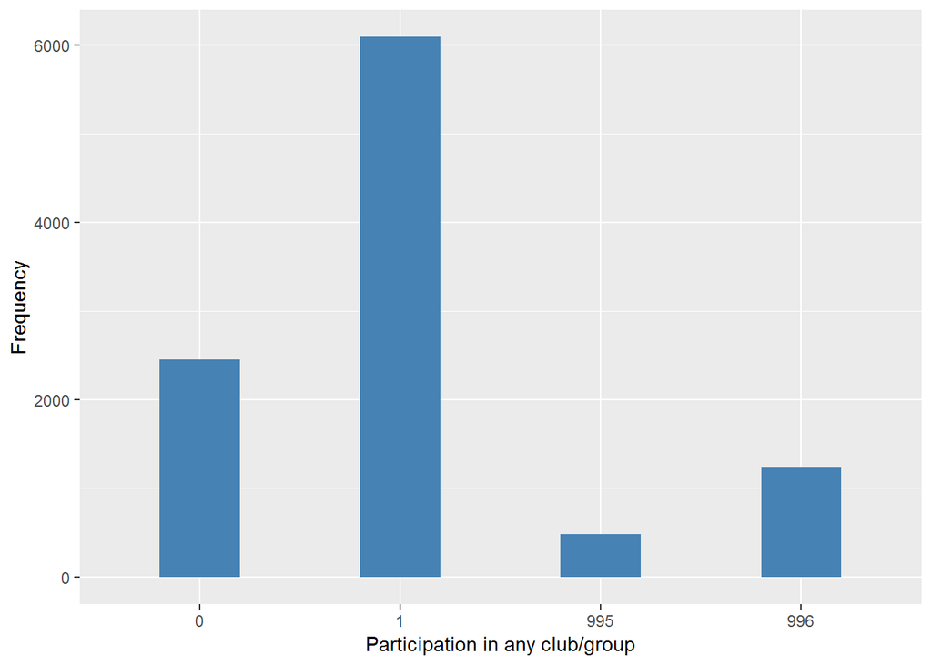

#### 2.1.5.4 Validation

### 2.1.6 Wave 6

#### 2.1.6.1 Study-specific variable description

The study-specific variable elected to be harmonised is:

- Name: `scorg01`
- Label: `Are you a member of: Political party, trade union or environmental groups`
- Categories:
  - `0 = No`
  - `1 = Yes`
- Missings:
  - `-9 = Not answered`
  - `-8 = Don't know`
  - `-2 = Schedule Not Applicable`
  - `-1 = Item not applicable`
- Name: `scorg02`
- Label: `Tenants groups, resident groups, neighbourhoold watch`
- Categories:
  - `0 = No`
  - `1 = Yes`
- Missings:
  - `-9 = Not answered`
  - `-8 = Don't know`
  - `-2 = Schedule Not Applicable`
  - `-1 = Item not applicable`
- Name: `scorg03`
- Label: `Church or other religious groups`
- Categories:
  - `0 = No`
  - `1 = Yes`
- Missings:
  - `-9 = Not answered`
  - `-8 = Don't know`
  - `-2 = Schedule Not Applicable`
  - `-1 = Item not applicable`
- Name: `scorg04`
- Label: `Charitable associations`
- Categories:
  - `0 = No`
  - `1 = Yes`
- Missings:
  - `-9 = Not answered`
  - `-8 = Don't know`
  - `-2 = Schedule Not Applicable`
  - `-1 = Item not applicable`
- Name: `scorg05`
- Label: `Education, art or music groups or evening classes`
- Categories:
  - `0 = No`
  - `1 = Yes`
- Missings:
  - `-9 = Not answered`
  - `-8 = Don't know`
  - `-2 = Schedule Not Applicable`
  - `-1 = Item not applicable`
- Name: `scorg06`
- Label: `Social club`
- Categories:
  - `0 = No`
  - `1 = Yes`
- Missings:
  - `-9 = Not answered`
  - `-8 = Don't know`
  - `-1 = Item not applicable`
- Name: `scorg07`
- Label: `Sports clubs, gym, exercise classes`
- Categories:
  - `0 = No`
  - `1 = Yes`
- Missings:
  - `-9 = Not answered`
  - `-8 = Don't know`
  - `-2 = Schedule Not Applicable`
  - `-1 = Item not applicable`
- Name: `scorg08`
- Label: `Any other organisations, club or societies`
- Categories:
  - `0 = No`
  - `1 = Yes`
- Missings:
  - `-9 = Not answered`
  - `-8 = Don't know`
  - `-2 = Schedule Not Applicable`
  - `-1 = Item not applicable`
- Name: `scorg09`
- Label: `No, I am not a member of any organisations, clubs or societies`
- Categories:
  - `0 = No`
  - `1 = Yes`
- Missings:
  - `-9 = Not answered`
  - `-8 = Don't know`
  - `-2 = Schedule Not Applicable`
  - `-1 = Item not applicable`

```
## $values_table
##                -9      -2       0       1
## Frequency  422.00 1604.00 7395.00 1180.00
## Percentage   3.98   15.13   69.76   11.13
##
## $n_table
##      Sample size Missing values
## [1,]       10601              0
```

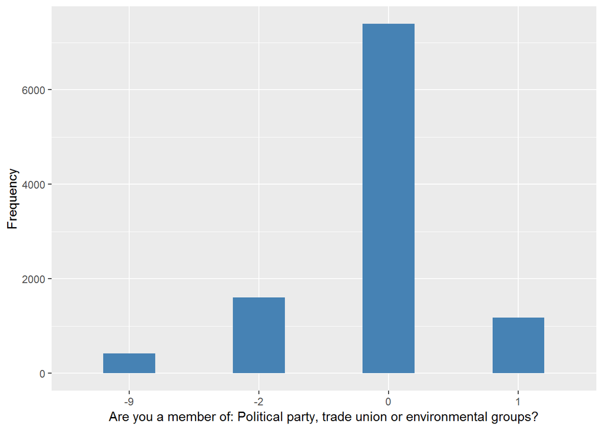

#### 2.1.6.2 Harmonisation algorithm

To compute the harmonize variable from the study-specific variable it has to be recoded as follows:

- `if any of scorg01-scorg08 equals 1 then 1`
- `if scorg09=1 or all of scorg01-scorg08 are equal 0 then 0`
- `-1 or -2 into 996`
- `-8 into 998`
- `-9 into 995`
- `NA into 999`

**R script:**

```r
ELSA_ds_w6 <- tibble(id = ELSA_w6_part_clubs$id)

ELSA_w6_part_clubs$scorg01 <- car::recode(as.vector(ELSA_w6_part_clubs$scorg01),
    "NA='-999'")
ELSA_w6_part_clubs$scorg02 <- car::recode(as.vector(ELSA_w6_part_clubs$scorg02),
    "NA='-999'")
ELSA_w6_part_clubs$scorg03 <- car::recode(as.vector(ELSA_w6_part_clubs$scorg03),
    "NA='-999'")
ELSA_w6_part_clubs$scorg04 <- car::recode(as.vector(ELSA_w6_part_clubs$scorg04),
    "NA='-999'")
ELSA_w6_part_clubs$scorg05 <- car::recode(as.vector(ELSA_w6_part_clubs$scorg05),
    "NA='-999'")
ELSA_w6_part_clubs$scorg06 <- car::recode(as.vector(ELSA_w6_part_clubs$scorg06),
    "NA='-999'")
ELSA_w6_part_clubs$scorg07 <- car::recode(as.vector(ELSA_w6_part_clubs$scorg07),
    "NA='-999'")
ELSA_w6_part_clubs$scorg08 <- car::recode(as.vector(ELSA_w6_part_clubs$scorg08),
    "NA='-999'")
ELSA_w6_part_clubs$scorg09 <- car::recode(as.vector(ELSA_w6_part_clubs$scorg09),
    "NA='-999'")

ELSA_ds_w6$part_clubs <- c(NA)
for (i in 1:dim(ELSA_w6_part_clubs)[1]) {
    if (ELSA_w6_part_clubs$scorg01[i] == 1 | ELSA_w6_part_clubs$scorg02[i] ==
        1 | ELSA_w6_part_clubs$scorg03[i] == 1 | ELSA_w6_part_clubs$scorg04[i] ==
        1 | ELSA_w6_part_clubs$scorg05[i] == 1 | ELSA_w6_part_clubs$scorg06[i] ==
        1 | ELSA_w6_part_clubs$scorg07[i] == 1 | ELSA_w6_part_clubs$scorg08[i] ==
        1) {
        ELSA_ds_w6$part_clubs[i] = 1
    } else if (ELSA_w6_part_clubs$scorg09[i] == 1 | (ELSA_w6_part_clubs$scorg01[i] ==
        0 & ELSA_w6_part_clubs$scorg02[i] == 0 & ELSA_w6_part_clubs$scorg03[i] ==
        0 & ELSA_w6_part_clubs$scorg04[i] == 0 & ELSA_w6_part_clubs$scorg05[i] ==
        0 & ELSA_w6_part_clubs$scorg06[i] == 0 & ELSA_w6_part_clubs$scorg07[i] ==
        0 & ELSA_w6_part_clubs$scorg08[i] == 0)) {
        ELSA_ds_w6$part_clubs[i] = 0
    } else if (ELSA_w6_part_clubs$scorg01[i] %in% c(-1, -2) | ELSA_w6_part_clubs$scorg02[i] %in%
        c(-1, -2) | ELSA_w6_part_clubs$scorg03[i] %in% c(-1, -2) | ELSA_w6_part_clubs$scorg04[i] %in%
        c(-1, -2) | ELSA_w6_part_clubs$scorg05[i] %in% c(-1, -2) | ELSA_w6_part_clubs$scorg06[i] %in%
        c(-1, -2) | ELSA_w6_part_clubs$scorg07[i] %in% c(-1, -2) | ELSA_w6_part_clubs$scorg08[i] %in%
        c(-1, -2) | ELSA_w6_part_clubs$scorg09[i] %in% c(-1, -2)) {
        ELSA_ds_w6$part_clubs[i] = 996
    } else if (ELSA_w6_part_clubs$scorg01[i] == -8 | ELSA_w6_part_clubs$scorg02[i] ==
        -8 | ELSA_w6_part_clubs$scorg03[i] == -8 | ELSA_w6_part_clubs$scorg04[i] ==
        -8 | ELSA_w6_part_clubs$scorg05[i] == -8 | ELSA_w6_part_clubs$scorg06[i] ==
        -8 | ELSA_w6_part_clubs$scorg07[i] == -8 | ELSA_w6_part_clubs$scorg08[i] ==
        -8 | ELSA_w6_part_clubs$scorg09[i] == -8) {
        ELSA_ds_w6$part_clubs[i] = 998
    } else if (ELSA_w6_part_clubs$scorg01[i] == -9 | ELSA_w6_part_clubs$scorg02[i] ==
        -9 | ELSA_w6_part_clubs$scorg03[i] == -9 | ELSA_w6_part_clubs$scorg04[i] ==
        -9 | ELSA_w6_part_clubs$scorg05[i] == -9 | ELSA_w6_part_clubs$scorg06[i] ==
        -9 | ELSA_w6_part_clubs$scorg07[i] == -9 | ELSA_w6_part_clubs$scorg08[i] ==
        -9 | ELSA_w6_part_clubs$scorg09[i] == -9) {
        ELSA_ds_w6$part_clubs[i] = 995
    }
}

ELSA_ds_w6$part_clubs <- car::recode(as.vector(ELSA_ds_w6$part_clubs), "NA='999'")
ELSA_ds_w6$part_clubs <- labelled(ELSA_ds_w6$part_clubs, labels = c(No = 0,
    Yes = 1, Missing = 999, `Do not know` = 998, Refuse = 997, `Not applicable` = 996,
    `Don't answer` = 995, `Not attempt/not done/not yet recorded` = 994, `Disable to measure` = 993,
    Impute = 992, `CAPI/interviewer error` = 991))
```

#### 2.1.6.3 Statistics of the new harmonised variable

```
## $values_table
##                  0       1
## Frequency  2482.00 6093.00
## Percentage   23.41   57.48
##
## $missing_values_table
##            991 992 993 994    995     996 997 998 999 NA
## Frequency    0   0   0   0 422.00 1604.00   0   0   0  0
## Percentage   0   0   0   0   3.98   15.13   0   0   0  0
##
## $n_table
##      Sample size Missing values
## [1,]       10601           2026
```

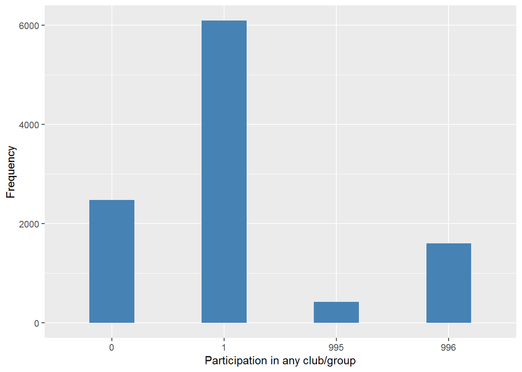

#### 2.1.6.4 Validation

### 2.1.7 Wave 7

#### 2.1.7.1 Study-specific variable description

The study-specific variable elected to be harmonised is:

- Name: `scorg01`
- Label: `Are you a member of: Political party, trade union or environmental groups`
- Categories:
  - `0 = No`
  - `1 = Yes`
- Missings:
  - `-9 = Not answered`
  - `-8 = Don't know`
  - `-2 = Schedule Not Applicable`
  - `-1 = Item not applicable`
- Name: `scorg02`
- Label: `Tenants groups, resident groups, neighbourhoold watch`
- Categories:
  - `0 = No`
  - `1 = Yes`
- Missings:
  - `-9 = Not answered`
  - `-8 = Don't know`
  - `-2 = Schedule Not Applicable`
  - `-1 = Item not applicable`
- Name: `scorg03`
- Label: `Church or other religious groups`
- Categories:
  - `0 = No`
  - `1 = Yes`
- Missings:
  - `-9 = Not answered`
  - `-8 = Don't know`
  - `-2 = Schedule Not Applicable`
  - `-1 = Item not applicable`
- Name: `scorg04`
- Label: `Charitable associations`
- Categories:
  - `0 = No`
  - `1 = Yes`
- Missings:
  - `-9 = Not answered`
  - `-8 = Don't know`
  - `-2 = Schedule Not Applicable`
  - `-1 = Item not applicable`
- Name: `scorg05`
- Label: `Education, art or music groups or evening classes`
- Categories:
  - `0 = No`
  - `1 = Yes`
- Missings:
  - `-9 = Not answered`
  - `-8 = Don't know`
  - `-2 = Schedule Not Applicable`
  - `-1 = Item not applicable`
- Name: `scorg06`
- Label: `Social club`
- Categories:
  - `0 = No`
  - `1 = Yes`
- Missings:
  - `-9 = Not answered`
  - `-8 = Don't know`
  - `-1 = Item not applicable`
- Name: `scorg07`
- Label: `Sports clubs, gym, exercise classes`
- Categories:
  - `0 = No`
  - `1 = Yes`
- Missings:
  - `-9 = Not answered`
  - `-8 = Don't know`
  - `-2 = Schedule Not Applicable`
  - `-1 = Item not applicable`
- Name: `scorg08`
- Label: `Any other organisations, club or societies`
- Categories:
  - `0 = No`
  - `1 = Yes`
- Missings:
  - `-9 = Not answered`
  - `-8 = Don't know`
  - `-2 = Schedule Not Applicable`
  - `-1 = Item not applicable`
- Name: `scorg09`
- Label: `No, I am not a member of any organisations, clubs or societies`
- Categories:
  - `0 = No`
  - `1 = Yes`
- Missings:
  - `-9 = Not answered`
  - `-8 = Don't know`
  - `-2 = Schedule Not Applicable`
  - `-1 = Item not applicable`

```
## $values_table
##                -9     -2       0       1
## Frequency  394.00 1469.0 6791.00 1012.00
## Percentage   4.08   15.2   70.26   10.47
##
## $n_table
##      Sample size Missing values
## [1,]        9666              0
```

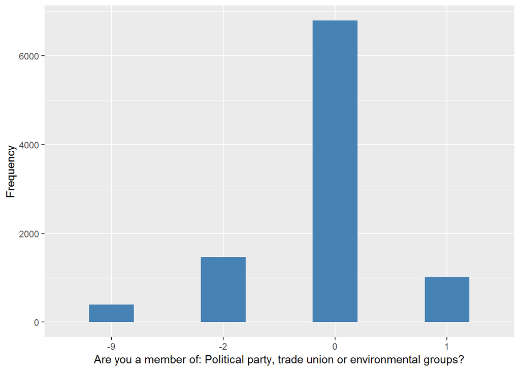

#### 2.1.7.2 Harmonisation algorithm

To compute the harmonize variable from the study-specific variable it has to be recoded as follows:

- `if any of scorg01-scorg08 equals 1 then 1`
- `if scorg09=1 or all of scorg01-scorg08 are equal 0 then 0`
- `-1 or -2 into 996`
- `-8 into 998`
- `-9 into 995`
- `NA into 999`

**R script:**

```r
ELSA_ds_w7 <- tibble(id = ELSA_w7_part_clubs$id)

ELSA_w7_part_clubs$scorg01 <- car::recode(as.vector(ELSA_w7_part_clubs$scorg01),
    "NA='-999'")
ELSA_w7_part_clubs$scorg02 <- car::recode(as.vector(ELSA_w7_part_clubs$scorg02),
    "NA='-999'")
ELSA_w7_part_clubs$scorg03 <- car::recode(as.vector(ELSA_w7_part_clubs$scorg03),
    "NA='-999'")
ELSA_w7_part_clubs$scorg04 <- car::recode(as.vector(ELSA_w7_part_clubs$scorg04),
    "NA='-999'")
ELSA_w7_part_clubs$scorg05 <- car::recode(as.vector(ELSA_w7_part_clubs$scorg05),
    "NA='-999'")
ELSA_w7_part_clubs$scorg06 <- car::recode(as.vector(ELSA_w7_part_clubs$scorg06),
    "NA='-999'")
ELSA_w7_part_clubs$scorg07 <- car::recode(as.vector(ELSA_w7_part_clubs$scorg07),
    "NA='-999'")
ELSA_w7_part_clubs$scorg08 <- car::recode(as.vector(ELSA_w7_part_clubs$scorg08),
    "NA='-999'")
ELSA_w7_part_clubs$scorg09 <- car::recode(as.vector(ELSA_w7_part_clubs$scorg09),
    "NA='-999'")

ELSA_ds_w7$part_clubs <- c(NA)
for (i in 1:dim(ELSA_w7_part_clubs)[1]) {
    if (ELSA_w7_part_clubs$scorg01[i] == 1 | ELSA_w7_part_clubs$scorg02[i] ==
        1 | ELSA_w7_part_clubs$scorg03[i] == 1 | ELSA_w7_part_clubs$scorg04[i] ==
        1 | ELSA_w7_part_clubs$scorg05[i] == 1 | ELSA_w7_part_clubs$scorg06[i] ==
        1 | ELSA_w7_part_clubs$scorg07[i] == 1 | ELSA_w7_part_clubs$scorg08[i] ==
        1) {
        ELSA_ds_w7$part_clubs[i] = 1
    } else if (ELSA_w7_part_clubs$scorg09[i] == 1 | (ELSA_w7_part_clubs$scorg01[i] ==
        0 & ELSA_w7_part_clubs$scorg02[i] == 0 & ELSA_w7_part_clubs$scorg03[i] ==
        0 & ELSA_w7_part_clubs$scorg04[i] == 0 & ELSA_w7_part_clubs$scorg05[i] ==
        0 & ELSA_w7_part_clubs$scorg06[i] == 0 & ELSA_w7_part_clubs$scorg07[i] ==
        0 & ELSA_w7_part_clubs$scorg08[i] == 0)) {
        ELSA_ds_w7$part_clubs[i] = 0
    } else if (ELSA_w7_part_clubs$scorg01[i] %in% c(-1, -2) | ELSA_w7_part_clubs$scorg02[i] %in%
        c(-1, -2) | ELSA_w7_part_clubs$scorg03[i] %in% c(-1, -2) | ELSA_w7_part_clubs$scorg04[i] %in%
        c(-1, -2) | ELSA_w7_part_clubs$scorg05[i] %in% c(-1, -2) | ELSA_w7_part_clubs$scorg06[i] %in%
        c(-1, -2) | ELSA_w7_part_clubs$scorg07[i] %in% c(-1, -2) | ELSA_w7_part_clubs$scorg08[i] %in%
        c(-1, -2) | ELSA_w7_part_clubs$scorg09[i] %in% c(-1, -2)) {
        ELSA_ds_w7$part_clubs[i] = 996
    } else if (ELSA_w7_part_clubs$scorg01[i] == -8 | ELSA_w7_part_clubs$scorg02[i] ==
        -8 | ELSA_w7_part_clubs$scorg03[i] == -8 | ELSA_w7_part_clubs$scorg04[i] ==
        -8 | ELSA_w7_part_clubs$scorg05[i] == -8 | ELSA_w7_part_clubs$scorg06[i] ==
        -8 | ELSA_w7_part_clubs$scorg07[i] == -8 | ELSA_w7_part_clubs$scorg08[i] ==
        -8 | ELSA_w7_part_clubs$scorg09[i] == -8) {
        ELSA_ds_w7$part_clubs[i] = 998
    } else if (ELSA_w7_part_clubs$scorg01[i] == -9 | ELSA_w7_part_clubs$scorg02[i] ==
        -9 | ELSA_w7_part_clubs$scorg03[i] == -9 | ELSA_w7_part_clubs$scorg04[i] ==
        -9 | ELSA_w7_part_clubs$scorg05[i] == -9 | ELSA_w7_part_clubs$scorg06[i] ==
        -9 | ELSA_w7_part_clubs$scorg07[i] == -9 | ELSA_w7_part_clubs$scorg08[i] ==
        -9 | ELSA_w7_part_clubs$scorg09[i] == -9) {
        ELSA_ds_w7$part_clubs[i] = 995
    }
}

ELSA_ds_w7$part_clubs <- car::recode(as.vector(ELSA_ds_w7$part_clubs), "NA='999'")
ELSA_ds_w7$part_clubs <- labelled(ELSA_ds_w7$part_clubs, labels = c(No = 0,
    Yes = 1, Missing = 999, `Do not know` = 998, Refuse = 997, `Not applicable` = 996,
    `Don't answer` = 995, `Not attempt/not done/not yet recorded` = 994, `Disable to measure` = 993,
    Impute = 992, `CAPI/interviewer error` = 991))
```

#### 2.1.7.3 Statistics of the new harmonised variable

```
## $values_table
##                  0       1
## Frequency  2285.00 5518.00
## Percentage   23.64   57.09
##
## $missing_values_table
##            991 992 993 994    995    996 997 998 999 NA
## Frequency    0   0   0   0 394.00 1469.0   0   0   0  0
## Percentage   0   0   0   0   4.08   15.2   0   0   0  0
##
## $n_table
##      Sample size Missing values
## [1,]        9666           1863
```

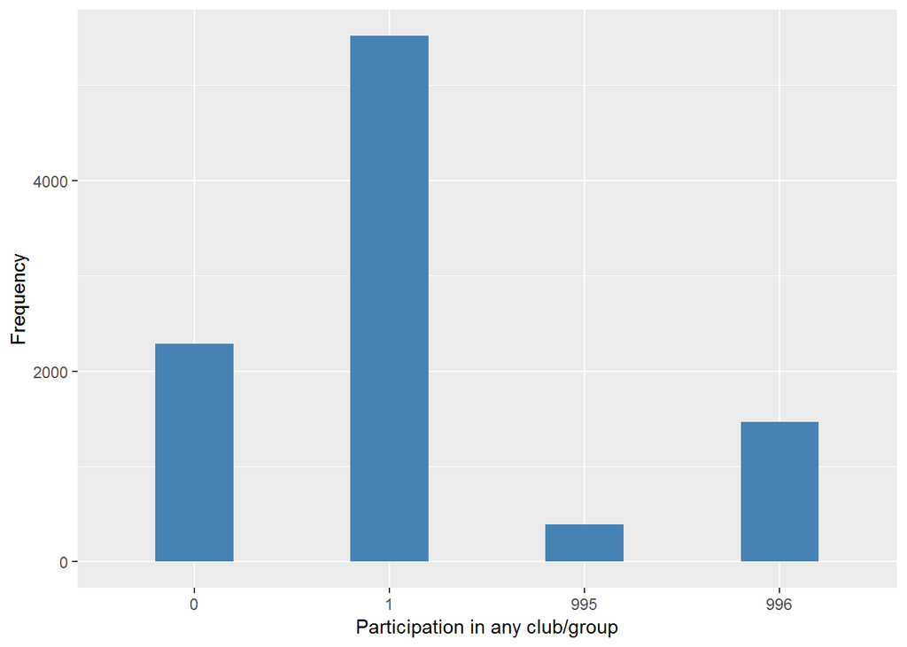

#### 2.1.7.4 Validation

## 2.2 Summary of descriptive statistics of the harmonised variable accross populations and waves

Two tables are generated:

1. Percentages of categories in each harmonised variable.
2. Frequencies and percentages of individuals with different trajectories. To avoid too large table, Only trajectories with percentages larger than 0.3 are shown.

```r
t.hds <- frq(l.hds[[1]][2])[[1]][, c(1, 2)]
for (i in seq_along(l.hds)) {
    t.hds[2 + i] <- frq(l.hds[[i]][2])[[1]][, 4]
}
t.hds[13, ] <- c("n", "sample size", sapply(l.hds, function(wave) length(wave[[1]])))
names(t.hds) <- c("val", "label", names(l.hds))
kable(t.hds)
```

| val | label | w1 | w2 | w3 | w4 | w5 | w6 | w7 |
| --- | --- | --- | --- | --- | --- | --- | --- | --- |
| 0 | No | 26.79 | 21.44 | 22.38 | 23.18 | 23.91 | 23.41 | 23.64 |
| 1 | Yes | 60.05 | 60.9 | 57.09 | 57.19 | 59.27 | 57.48 | 57.09 |
| 991 | CAPI interviewer error | 0 | 0 | 0 | 0 | 0 | 0 | 0 |
| 992 | Impute | 0 | 0 | 0 | 0 | 0 | 0 | 0 |
| 993 | Disable to measure | 0 | 0 | 0 | 0 | 0 | 0 | 0 |
| 994 | Not attempt not done | 0 | 0 | 0 | 0 | 0 | 0 | 0 |
| 995 | Does not answer | 4.01 | 6.3 | 4.9 | 4.18 | 4.72 | 3.98 | 4.08 |
| 996 | Not applicable | 9.16 | 11.37 | 15.63 | 15.46 | 12.11 | 15.13 | 15.2 |
| 997 | Refuse | 0 | 0 | 0 | 0 | 0 | 0 | 0 |
| 998 | Do not know | 0 | 0 | 0 | 0 | 0 | 0 | 0 |
| 999 | Missing | 0 | 0 | 0 | 0 | 0 | 0 | 0 |
| NA | NA | 0 | 0 | 0 | 0 | 0 | 0 | 0 |
| n | sample size | 12099 | 9432 | 9771 | 11050 | 10274 | 10601 | 9666 |

```r
dbb <- get(paste0("ELSA_m_ds_", names(l.hds)[1]))[, c("id", "part_clubs")]
for (ind in 2:length(l.hds)) {
    dbb <- merge(dbb, get(paste0("ELSA_m_ds_", names(l.hds)[ind]))[, c("id",
        "part_clubs")], by = "id", suffixes = c("", paste0(".", names(l.hds)[ind])),
        all = T)
}
names(dbb) <- c("id", names(l.hds))

v.dbb <- dbb[, 2]
for (ind in 2:length(l.hds)) {
    v.dbb <- paste(v.dbb, dbb[, ind + 1], sep = "")
}
f.dbb <- frq(v.dbb)[[1]][, c(1, 2, 4)]
kable(f.dbb[f.dbb[, 3] >= 0.3, ])
```

|  | val | frq | raw.prc |
| --- | --- | --- | --- |
| 1 | 0000000 | 107 | 0.58 |
| 65 | 000NANANANA | 125 | 0.68 |
| 163 | 00NANANANANA | 296 | 1.60 |
| 239 | 0111111 | 57 | 0.31 |
| 264 | 011NANANANA | 56 | 0.30 |
| 302 | 01NANANANANA | 91 | 0.49 |
| 347 | 0NA0NANANANA | 76 | 0.41 |
| 422 | 0NANANANANANA | 895 | 4.84 |
| 562 | 10NANANANANA | 106 | 0.57 |
| 662 | 1111111 | 1599 | 8.65 |
| 663 | 111111NA | 232 | 1.25 |
| 665 | 11111NA1 | 64 | 0.35 |
| 666 | 11111NANA | 176 | 0.95 |
| 671 | 1111NA11 | 64 | 0.35 |
| 674 | 1111NANANA | 202 | 1.09 |
| 687 | 111NA111 | 101 | 0.55 |
| 700 | 111NANANANA | 362 | 1.96 |
| 730 | 11NA1111 | 107 | 0.58 |
| 762 | 11NANANANANA | 613 | 3.32 |
| 820 | 1NA11111 | 93 | 0.50 |
| 845 | 1NA1NANANANA | 75 | 0.41 |
| 898 | 1NANANANANANA | 1240 | 6.71 |
| 959 | NA0NANANANANA | 81 | 0.44 |
| 1046 | NA1NANANANANA | 85 | 0.46 |
| 1047 | NANA00000 | 59 | 0.32 |
| 1109 | NANA0NANANANA | 111 | 0.60 |
| 1145 | NANA11111 | 243 | 1.31 |
| 1146 | NANA1111NA | 57 | 0.31 |
| 1180 | NANA1NANANANA | 164 | 0.89 |
| 1181 | NANANA0000 | 143 | 0.77 |
| 1183 | NANANA000NA | 57 | 0.31 |
| 1189 | NANANA00NANA | 60 | 0.32 |
| 1207 | NANANA0NANANA | 141 | 0.76 |
| 1221 | NANANA1111 | 711 | 3.85 |
| 1222 | NANANA111NA | 143 | 0.77 |
| 1225 | NANANA11NANA | 121 | 0.65 |
| 1234 | NANANA1NANANA | 212 | 1.15 |
| 1242 | NANANANA0NANA | 58 | 0.31 |
| 1247 | NANANANA111 | 89 | 0.48 |
| 1251 | NANANANA1NANA | 69 | 0.37 |
| 1252 | NANANANANA00 | 171 | 0.92 |
| 1253 | NANANANANA01 | 68 | 0.37 |
| 1254 | NANANANANA0NA | 130 | 0.70 |
| 1255 | NANANANANA10 | 62 | 0.34 |
| 1256 | NANANANANA11 | 408 | 2.21 |
| 1257 | NANANANANA1NA | 151 | 0.82 |
| 1258 | NANANANANANA0 | 190 | 1.03 |
| 1259 | NANANANANANA1 | 321 | 1.74 |
| 1260 | NANANANANANANA | 1753 | 9.48 |

# 3 Quality estimation